# New MAGE model in BaM

Felipe

2025-09-03

# Features in BaM for MAGE_ZQV_model:

The new features in BaM for the MAGE model calibration include:

- Model with 4 input variables:
  - **X1**: event number starting from 1.
  - **X2**: reach number starting from 1.
  - **X3**: position coordinate in the reach. Units depends on the MAGE projet.
  - **X4**: time coordinate in **seconds**.
- Model with 5 output variables. Units depends on the MAGE projet:
  - **Y1**: water surface elevation (WSE).
  - **Y2**: discharge.
  - **Y3**: velocity.
  - **Y4**: friction in the main channel (Kmin).
  - **Y5**: friction in the floodplain (Kmoy).
- Multiple events is supported.
- Multiple reaches is supported.
- Get simulation data using the `.BIN` file.
- Interpolation in time and space is supported.
- Spatialisation of the parameters using Legendre polynomial method is supported.

# Remarks:

- Add the idea of a hydraulic unit, which is a set of reaches with the same spatially distributed friction. This approach led us to manage the tributary and the main river differently.
- To run parallel calibration varying either the number of events or degree of the Legendre polynomial, it is mandatory to specify several folders.
- Spatial-temporal error model specified to each output variable: WSE, discharge, velocity, friction in the main channel, and friction in the floodplain **(need to be developed)**
- The model can receive velocity measurements during calibration, but it is necessary to implement the velocity simulaiton in mage based on wetted area and discharge to get the simulation data.

# Setup for the MAGE model

The data is stored in a text file named `CalibrationData.txt`. The data includes the following columns with -9999 as missing values:

- **Event**: event number.
- **Reach**: reach number.
- **x**: position coordinate in the reach.
- **t**: time coordinate in the reach.
- **Y_Z**: observed water surface elevation (WSE).
- **Y_Q**: observed discharge.
- **Y_V**: observed velocity.
- **Yu_Z**: uncertainty of the observed water surface elevation (WSE).
- **Yu_Q**: uncertainty of the observed discharge.
- **Yu_V**: uncertainty of the observed velocity.

| event | reach | x | t | WSE | Discharge | Velocity | Y_Kmin | Y_Kmoy | Yu_z | Yu_Q | Yu_V | Yu_Kmin | Yu_Kmoy |
| --- | --- | --- | --- | --- | --- | --- | --- | --- | --- | --- | --- | --- | --- |
| 1 | 1 | 0.06 | 3420 | 0.1125461 | -9999 | -9999 | -9999 | -9999 | 0.0009182 | -9999 | -9999 | -9999 | -9999 |
| 1 | 1 | 0.65 | 3420 | 0.1119325 | -9999 | -9999 | -9999 | -9999 | 0.0009182 | -9999 | -9999 | -9999 | -9999 |
| 1 | 1 | 1.65 | 3420 | 0.1110458 | -9999 | -9999 | -9999 | -9999 | 0.0009182 | -9999 | -9999 | -9999 | -9999 |
| 1 | 1 | 3.65 | 3420 | 0.1080834 | -9999 | -9999 | -9999 | -9999 | 0.0009182 | -9999 | -9999 | -9999 | -9999 |
| 1 | 1 | 5.65 | 3420 | 0.1060610 | -9999 | -9999 | -9999 | -9999 | 0.0009182 | -9999 | -9999 | -9999 | -9999 |
| 1 | 1 | 7.65 | 3420 | 0.1045160 | -9999 | -9999 | -9999 | -9999 | 0.0009182 | -9999 | -9999 | -9999 | -9999 |
| 1 | 1 | 9.65 | 3420 | 0.1021420 | -9999 | -9999 | -9999 | -9999 | 0.0009182 | -9999 | -9999 | -9999 | -9999 |
| 1 | 1 | 11.65 | 3420 | 0.1006603 | -9999 | -9999 | -9999 | -9999 | 0.0009182 | -9999 | -9999 | -9999 | -9999 |
| 2 | 1 | 0.06 | 3420 | 0.0782550 | -9999 | -9999 | -9999 | -9999 | 0.0005532 | -9999 | -9999 | -9999 | -9999 |
| 2 | 1 | 0.65 | 3420 | 0.0776414 | -9999 | -9999 | -9999 | -9999 | 0.0005532 | -9999 | -9999 | -9999 | -9999 |
| 2 | 1 | 1.65 | 3420 | 0.0766031 | -9999 | -9999 | -9999 | -9999 | 0.0005532 | -9999 | -9999 | -9999 | -9999 |
| 2 | 1 | 3.65 | 3420 | 0.0738700 | -9999 | -9999 | -9999 | -9999 | 0.0005532 | -9999 | -9999 | -9999 | -9999 |
| 2 | 1 | 5.65 | 3420 | 0.0716777 | -9999 | -9999 | -9999 | -9999 | 0.0005532 | -9999 | -9999 | -9999 | -9999 |
| 2 | 1 | 7.65 | 3420 | 0.0698072 | -9999 | -9999 | -9999 | -9999 | 0.0005532 | -9999 | -9999 | -9999 | -9999 |
| 2 | 1 | 9.65 | 3420 | 0.0672428 | -9999 | -9999 | -9999 | -9999 | 0.0005532 | -9999 | -9999 | -9999 | -9999 |
| 2 | 1 | 11.65 | 3420 | 0.0650094 | -9999 | -9999 | -9999 | -9999 | 0.0005532 | -9999 | -9999 | -9999 | -9999 |
| 3 | 1 | 0.06 | 3420 | 0.0572459 | -9999 | -9999 | -9999 | -9999 | 0.0004587 | -9999 | -9999 | -9999 | -9999 |
| 3 | 1 | 0.65 | 3420 | 0.0566323 | -9999 | -9999 | -9999 | -9999 | 0.0004587 | -9999 | -9999 | -9999 | -9999 |
| 3 | 1 | 1.65 | 3420 | 0.0560822 | -9999 | -9999 | -9999 | -9999 | 0.0004587 | -9999 | -9999 | -9999 | -9999 |
| 3 | 1 | 3.65 | 3420 | 0.0539269 | -9999 | -9999 | -9999 | -9999 | 0.0004587 | -9999 | -9999 | -9999 | -9999 |
| 3 | 1 | 5.65 | 3420 | 0.0515902 | -9999 | -9999 | -9999 | -9999 | 0.0004587 | -9999 | -9999 | -9999 | -9999 |
| 3 | 1 | 7.65 | 3420 | 0.0499854 | -9999 | -9999 | -9999 | -9999 | 0.0004587 | -9999 | -9999 | -9999 | -9999 |
| 3 | 1 | 9.65 | 3420 | 0.0476209 | -9999 | -9999 | -9999 | -9999 | 0.0004587 | -9999 | -9999 | -9999 | -9999 |
| 3 | 1 | 11.65 | 3420 | 0.0456141 | -9999 | -9999 | -9999 | -9999 | 0.0004587 | -9999 | -9999 | -9999 | -9999 |
| 4 | 1 | 0.06 | 3420 | 0.0435692 | -9999 | -9999 | -9999 | -9999 | 0.0004381 | -9999 | -9999 | -9999 | -9999 |
| 4 | 1 | 0.65 | 3420 | 0.0429556 | -9999 | -9999 | -9999 | -9999 | 0.0004381 | -9999 | -9999 | -9999 | -9999 |
| 4 | 1 | 1.65 | 3420 | 0.0422574 | -9999 | -9999 | -9999 | -9999 | 0.0004381 | -9999 | -9999 | -9999 | -9999 |
| 4 | 1 | 3.65 | 3420 | 0.0402545 | -9999 | -9999 | -9999 | -9999 | 0.0004381 | -9999 | -9999 | -9999 | -9999 |
| 4 | 1 | 5.65 | 3420 | 0.0379333 | -9999 | -9999 | -9999 | -9999 | 0.0004381 | -9999 | -9999 | -9999 | -9999 |
| 4 | 1 | 7.65 | 3420 | 0.0363895 | -9999 | -9999 | -9999 | -9999 | 0.0004381 | -9999 | -9999 | -9999 | -9999 |
| 4 | 1 | 9.65 | 3420 | 0.0339301 | -9999 | -9999 | -9999 | -9999 | 0.0004381 | -9999 | -9999 | -9999 | -9999 |
| 4 | 1 | 11.65 | 3420 | 0.0320205 | -9999 | -9999 | -9999 | -9999 | 0.0004381 | -9999 | -9999 | -9999 | -9999 |

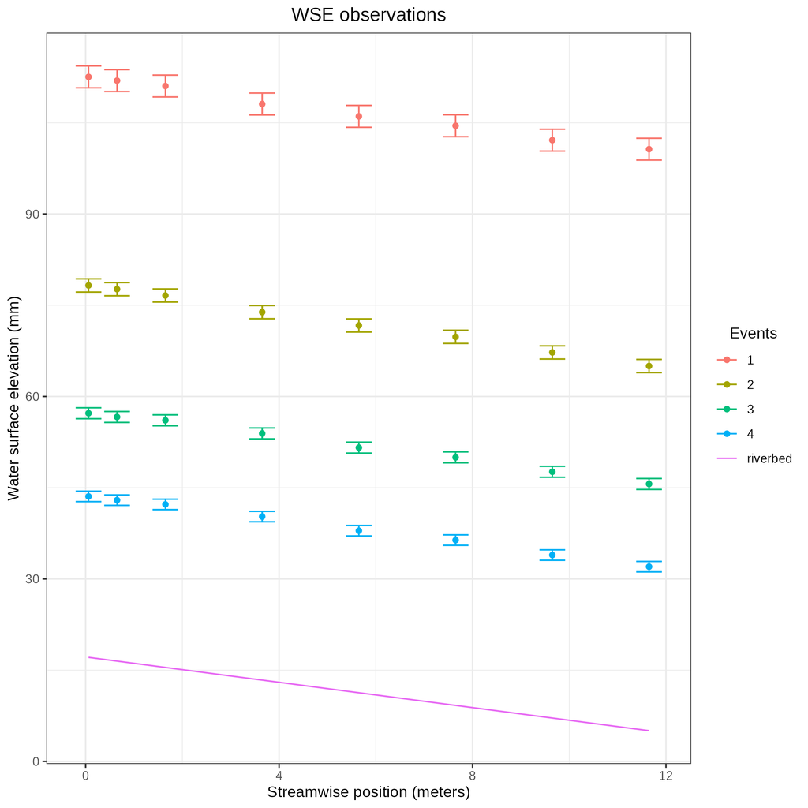

# Workflow

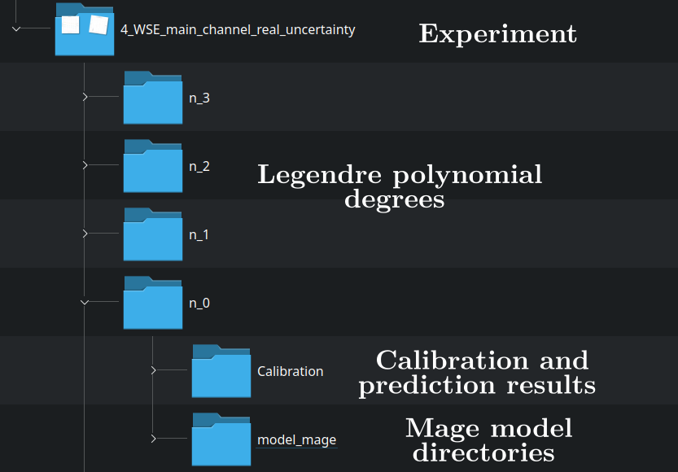

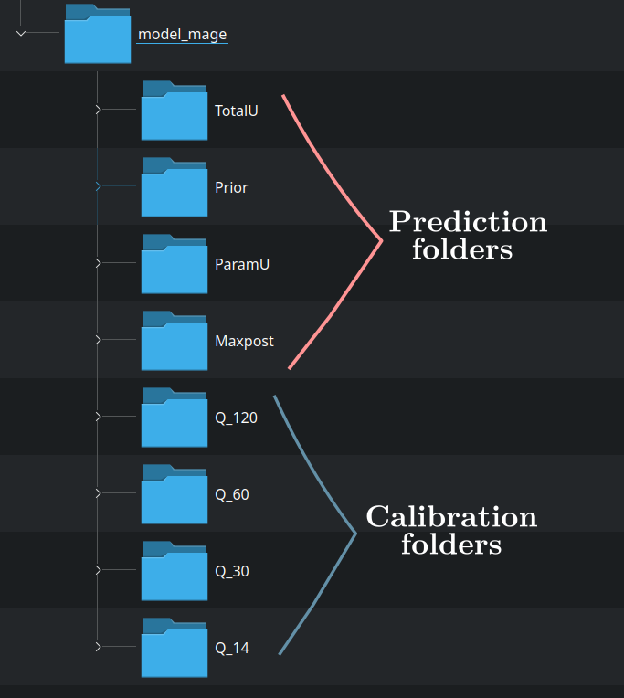